# Group Project 1

## Research Question 1: Which country is the poorest based on the MPI scale?

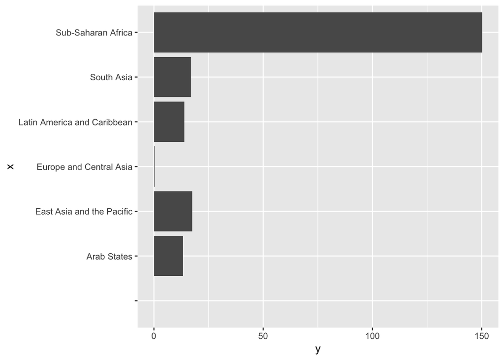

```r
p = ggplot(MPI_subnational, aes_string(x=MPI_subnational$World.region, y=MPI_subnational$MPI.Index..MPI...H.A....Range.0.to.1))
p + geom_col() + coord_flip()
```

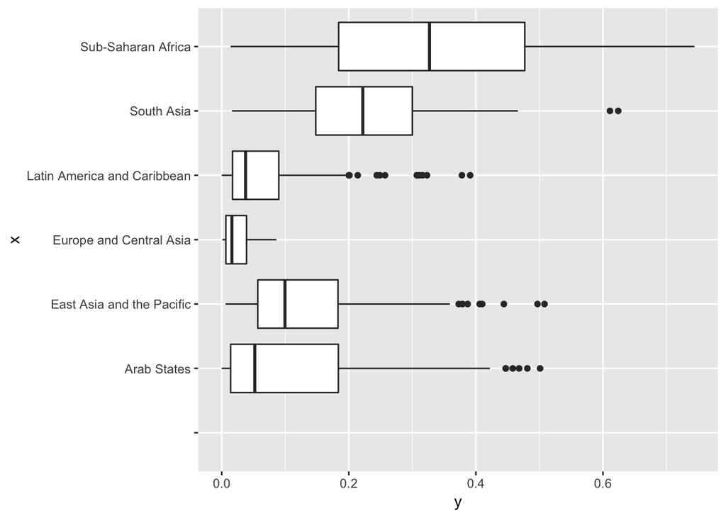

```r
p = ggplot(MPI_subnational, aes_string(x=MPI_subnational$World.region, y=MPI_subnational$MPI.Index..MPI...H.A....Range.0.to.1))
p +  geom_boxplot() +coord_flip()
```

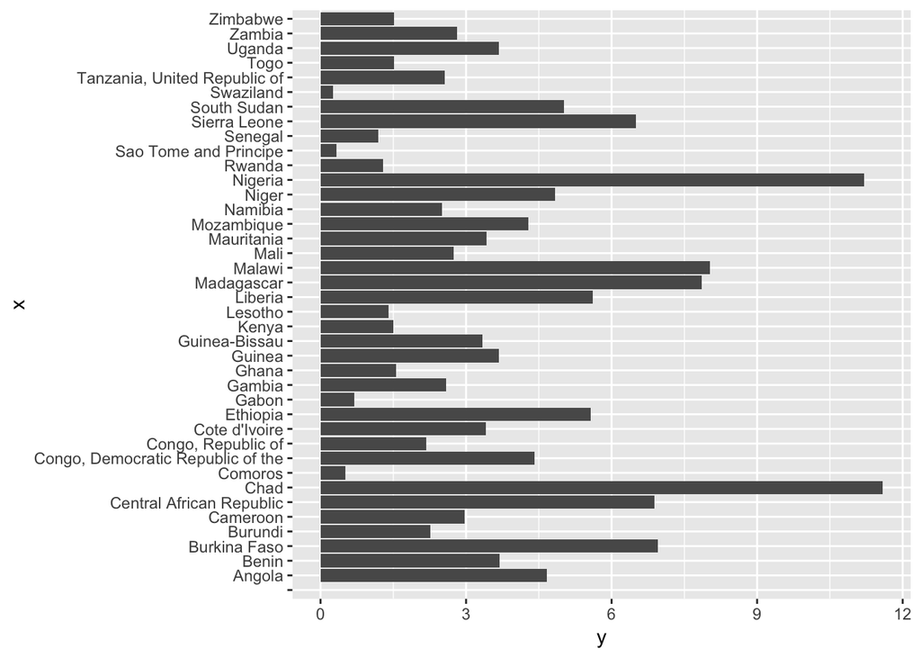

```r
# Isolated the Sub-saharan dataset and used it for graphical summary
ssh = read.csv("ssh.csv")
p = ggplot(ssh, aes_string(x=ssh$Country, y=ssh$Multidimensional.Poverty.Index..MPI..of.the.country))
p + geom_col() + coord_flip()
```

## Research Question 2:analyse the regional MPI index of that country.

In addition to providing data on multidimensional poverty at the national level, the MPI can also be broken down by sub-national regions to show disparities in poverty within countries. This analysis can be easily performed when the survey used for the MPI is representative at the sub-national level. (Oxford Poverty and Human Development Initiative,2017)

```r
original=read.csv("subnational.csv")
head(original)
```

[output not shown]

[output cut: 29 more lines]

[output not shown]

This table reports the Multidimensional Poverty Index, its two components - the Headcount Ratio and the Intensity of Deprivation among the poor - and other indicators of multidimensional poverty more than 1000 regions of more than 70 countries. The final columns show any missing indicators that might affect/ contribute to the information of the findings.

From this table, all the data relevant to Chad is further extract into a new set for details examination of the MPI in regions of Chad exclusively

```r
city=read.csv("Chad_21.csv")
city
```

```
##     X Sub.national.region    Year Survey.Type MPI..HxA.
## 1   1       Barh El Gazal 2014/15         DHS     0.654
## 2   2               Batha 2014/15         DHS     0.659
## 3   3      Borkou/Tibesti 2014/15         DHS     0.537
## 4   4      Chari Baguirmi 2014/15         DHS     0.646
## 5   5              Ennedi 2014/15         DHS     0.625
## 6   6               Guéra 2014/15         DHS     0.643
## 7   7        Hadjer-Lamis 2014/15         DHS     0.654
## 8   8               Kanem 2014/15         DHS     0.696
## 9   9                 Lac 2014/15         DHS     0.744
## 10 10   Logone Occidental 2014/15         DHS     0.440
## 11 11     Logone Oriental 2014/15         DHS     0.504
## 12 12             Mandoul 2014/15         DHS     0.529
## 13 13      Mayo Kebbi Est 2014/15         DHS     0.509
## 14 14    Mayo Kebbi Ouest 2014/15         DHS     0.479
```

[output cut: 95 more lines]

```r
names(city)
```

```
##  [1] "X"
##  [2] "Sub.national.region"
##  [3] "Year"
##  [4] "Survey.Type"
##  [5] "MPI..HxA."
##  [6] "Headcount.ratio..H."
##  [7] "Intensity.of.deprivation.among.the.poor...A.."
##  [8] "X..Vulnerable.to.poverty.."
##  [9] "Population.in..severe.poverty."
## [10] "Destitutes....Population."
## [11] "Inequality.among.the.poor"
## [12] "Population.Share.of.the.Region"
```

The following table shows the MPI at the Sub-national Level value with the following measurement:

- MPI is calculate by including the **the incidence of poverty (H)** and the **average intensity of deprivation across the poor (A)**.

The bar grapgh below The MPI assesses poverty at the individual level. If someone is deprived in a third or more of ten indicators, the global index identifies them as ‘MPI poor’, and the extent – or intensity – of their poverty is measured by the number of deprivations they are experiencing.

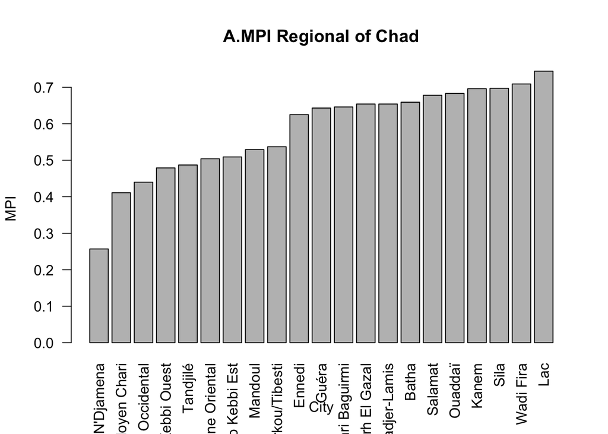

```r
barplot(city$MPI..HxA.[order(city$MPI..HxA.)], names = city$Sub.national.region[order(city$MPI..HxA.)],
        xlab = "City", ylab = "MPI", main = "A.MPI Regional of Chad", las = 2)
```

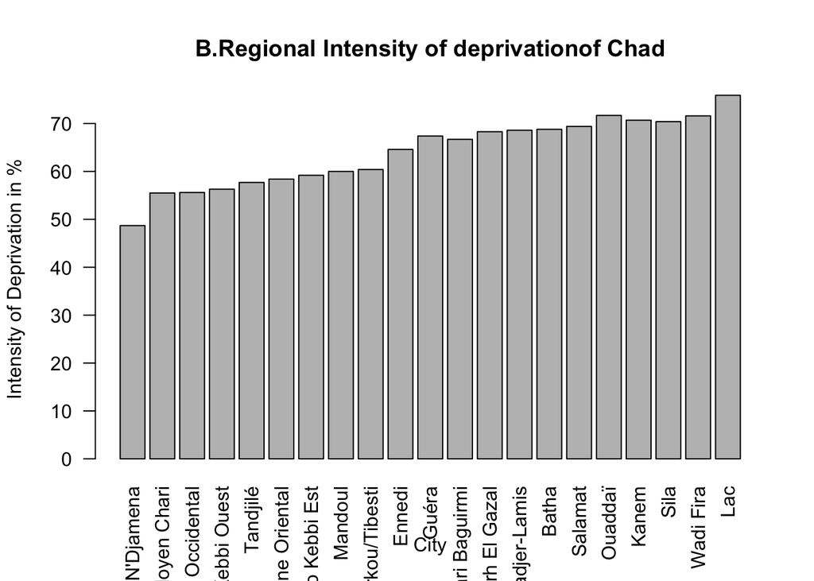

```r
barplot(city$Intensity.of.deprivation.among.the.poor...A..[order(city$MPI..HxA.)], names = city$Sub.national.region[order(city$MPI..HxA.)],
        xlab = "City", ylab = "Intensity of Deprivation in %", main = " B.Regional Intensity of deprivationof Chad ",las=2)
```

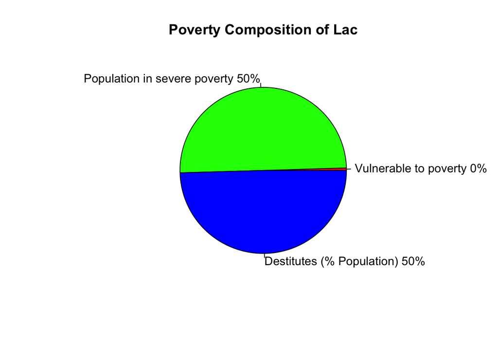

```r
slices <- c(0.9,92.7,91.9)
lbls <- c("Vulnerable to poverty","Population in severe poverty","Destitutes (% Population)")
pct <- round(slices/sum(slices)*100)
lbls <- paste(lbls, pct) # add percents to labels
lbls <- paste(lbls,"%",sep="") # ad % to labels
pie(slices,labels = lbls, col=rainbow(length(lbls)),
    main="Poverty Composition of Lac")
```

```r
## Research Question 3
```

```r
head(excel_subnational)
```

```
##     X         X.1        X.2        X.3 Survey    Year  X.4   X.5 X.6
## 1                                                              NA  NA
## 2                                                              NA  NA
## 3 AFG Afghanistan Badakhshan South Asia    DHS 2015/16 3.3% 0.387  NA
## 4 AFG Afghanistan    Badghis South Asia    DHS 2015/16 2.1% 0.466  NA
## 5 AFG Afghanistan    Baghlan South Asia    DHS 2015/16 2.8% 0.300  NA
## 6 AFG Afghanistan      Balkh South Asia    DHS 2015/16 6.2% 0.301  NA
##        Education         Health Living..standards X.7      Schooling
## 1 % Contribution % Contribution    % Contribution  NA % Contribution
## 2                                                  NA
## 3           26.6           37.4              36.0  NA            9.6
## 4           34.4           24.7              40.9  NA           18.7
## 5           31.8           30.8              37.5  NA            9.6
## 6           30.2           41.6              28.2  NA           12.8
##   Child.school.attendance X.8 Child.Mortality      Nutrition X.9
```

[output cut: 20 more lines]

# Research Question 3:Which factors contribute the most to Chad’s poverty ?

From the excel_subnational dataset, it illustrates that living standards is the most relevant factor that has contributed to Chad’s poverty. 41.4% of the population have living standards that are destitute in the urban area of Chad. However, in the rural areas of Chad, the percentage contributino of deprivation of living standard to overall poverty is 45.2%.

In Lac, which is the poorest city in Chad, the percentage contribution of deprivation of living standard to overall poverty is 39.2%. Within the main category of living standard in Lac, Electricity, Improved sanitation and Cooking fuel are the top 3 categories that have been proven to be below the poverty line. In conclusion, Electricity, Improved sanitation and Cooking fuel are the factors which contribute the most to Chad’s poverty.

# Conclusions

## Links

For more comprehensive analysis of MPI: [Interesting Web Page](https://www.kaggle.com/pcharambira/analysis-of-multidimensional-poverty-measures)

## References

Kaggle.com. (2018). Multidimensional Poverty Measures | Kaggle. [online] Available at: https://www.kaggle.com/ophi/mpi [Accessed 11 Aug. 2018].

Alkire, S. and Robles, G. (2017). “Multidimensional Poverty Index Summer 2017: Brief methodological note and results.” OPHI Methodological Note 44, University of Oxford.

Alkire, S. and Santos, M. E. (2010). “Acute multidimensional poverty: A new index for developing countries.” OPHI Working Papers 38, University of Oxford.

Alkire, S. Jindra, C. Robles, G. and Vaz, A. (2017). ‘Multidimensional Poverty Index – Summer 2017: brief methodological note and results’. OPHI MPI Methodological Notes No. 44, Oxford Poverty and Human Development Initiative, University of Oxford.

Charambira, P. (2018). Analysis of Multidimensional Poverty Measures | Kaggle. Retrieved from https://www.kaggle.com/pcharambira/analysis-of-multidimensional-poverty-measures

Alkire, S. and Kanagaratnam, U. (2018) Multidimensional Poverty Index Winter 2017-18: Brief methodological note and results.Oxford Poverty and Human Development Initiative, University of Oxford, OPHI Methodological Notes 45.

Oxford Poverty and Human Development Initiative (2017). “Chad Country Briefing”, Multidimensional Poverty Index Data Bank. OPHI, University of Oxford. Available at: www.ophi.org.uk/multidimensional-poverty-index/mpi-country-briefings/.

MPI methodology, see Alkire, S. and Robles, G. (2017), “Multidimensional Poverty Index 2017: BriefMethodological Note and Results”. Available at: www.ophi.org.uk/multidimensional-poverty-index /.

## Personal reflection on group work

- The way I contributed was doing the executive summary, IDA, conclusions and Research Question One.
- The group work was very enjoyable, I thoroughly enjoyed extractng the dataset and finding conclusions and patterns with the data.